# Data Collection

Amber Thomas

10/29/2018

## Introduction

This is an exploration into the following question:

**How do public high schools police bodies differently?**

As such, I have been surveying public high schools with available dress codes (and no uniform policy) across the US and collecting information from them in this [Google Form](https://docs.google.com/forms/d/e/1FAIpQLSdtoXVKL9oFfDVigRmfKUYPJBguZSdUlcgplu9F8XrCa9nJ_w/viewform?usp=sf_link). The attire items listed are a combination of those collected by Jaymie Arns in their [Master’s Thesis](https://csus-dspace.calstate.edu/bitstream/handle/10211.3/198629/Jaymie%20Arns%20-%20Masters%20Thesis.pdf?sequence=1).

## Loading Packages

To start, I’ll only need a few packages, mostly to connect me with the Google Sheets where the data from my form is being collected.

```r
library(tidyverse)
library(here)
```

## Downloading Data from Google Sheets

```r
sheetID <- googledrive::as_id("https://docs.google.com/spreadsheets/d/1TgmALnY8qc8Aahy1QdV0CvX_SNl4sL6ErPpWwYcdfOk/edit#gid=602462357")

googledrive::drive_download(sheetID, path = here("raw_data", "dress_codes.csv"), overwrite = TRUE)

dressCodes <- read.csv(here::here("raw_data", "dress_codes.csv"), stringsAsFactors = FALSE, header = TRUE, na.strings = c("", " ", "none"))
```

## Organizing the Data

Because of the way that Google Sheets works, we end up with very *wide* data. That is, each clothing item is listed as a column instead of having several rows per school. Therefore, my data needs to go from wide to long.

```r
sub <- dressCodes[, 0:20]

col <- as.data.frame(colnames(sub)) %>%
  filter(grepl("accessories", colnames(sub)))

subLong <- sub %>%
  gather(key = item, value = prohibited, colnames(select(sub, contains("accessories")))) %>%
  filter(!is.na(prohibited)) %>%
  mutate(item = gsub("(.*\\.{3})", "", item),
         item = gsub("\\.", " ", item),
         item = trimws(item)) %>%
  mutate(type = "accessories")

test <- colnames(select(sub, contains("accessories")))

test2 <- colnames(select(dressCodes, matches("\\baccessories\\b.*?\\bgender\\b")))
```

Now to turn this into a function to map across multiple sections

```r
elongateCode <- function(type){
  regex <- paste0("\\b", type, "\\b.*?\\gender\\b")
  bonusColumn <- colnames(select(dressCodes, matches(regex)))

  new <- dressCodes %>%
    # First sort out any additional items that we added to our bonus column
    separate_rows_(bonusColumn, sep = ",") %>%
    separate(bonusColumn, into = c("item", "prohibited"), sep = "-") %>%
    mutate(type = type) %>%
    select(c(1:6), c(item, prohibited, type)) %>%
    filter(!is.na(prohibited))

  new2 <- dressCodes %>%
    select(-contains("item.gender")) %>%
    gather(key = item, value = prohibited, colnames(select(., contains(!!type)))) %>%
    filter(!is.na(prohibited)) %>%
    mutate(item = gsub("(.*\\.{3})", "", item),
         item = gsub("\\.", " ", item),
         item = trimws(item)) %>%
    mutate(type = type) %>%
    select(c(1:6), c(item:type))

  combined <- rbind(new, new2)
}

clothingTypes <- c("accessories", "belt", "shirt", "dress.items", "skirt", "pants", "shorts", "undergarment", "clothing", "footwear", "headwear", "body")

longDressCode <- map_dfr(clothingTypes, elongateCode)

write.csv(longDressCode, here("processed_data", "clean_dress_code.csv"), row.names = FALSE)
```

## Exploring Data

### Body Parts

Which body parts are specifically prohibited the most on high school campuses?

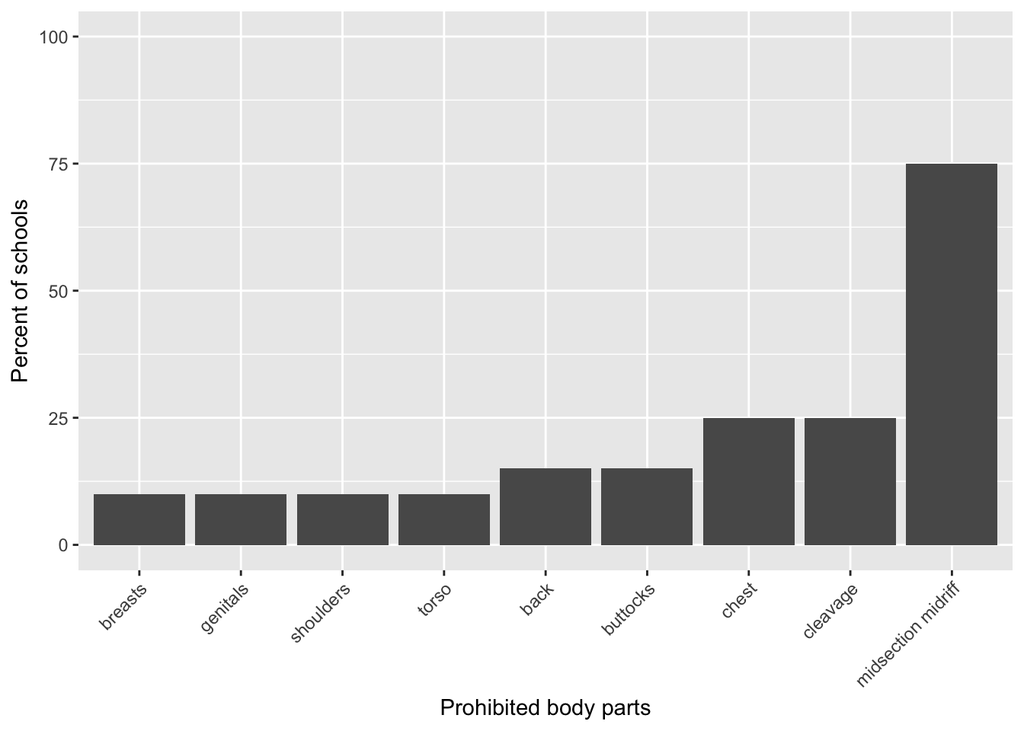

### Clothing Types

What types of clothing have been specifically prohibited?

#### Shirts

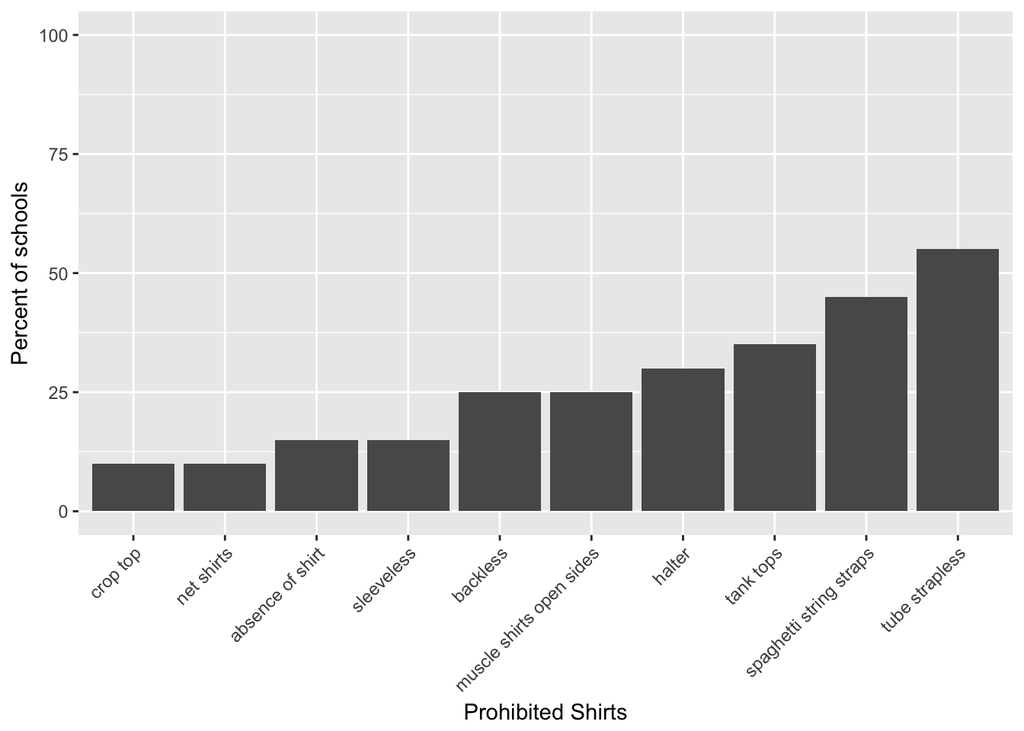

#### Shorts

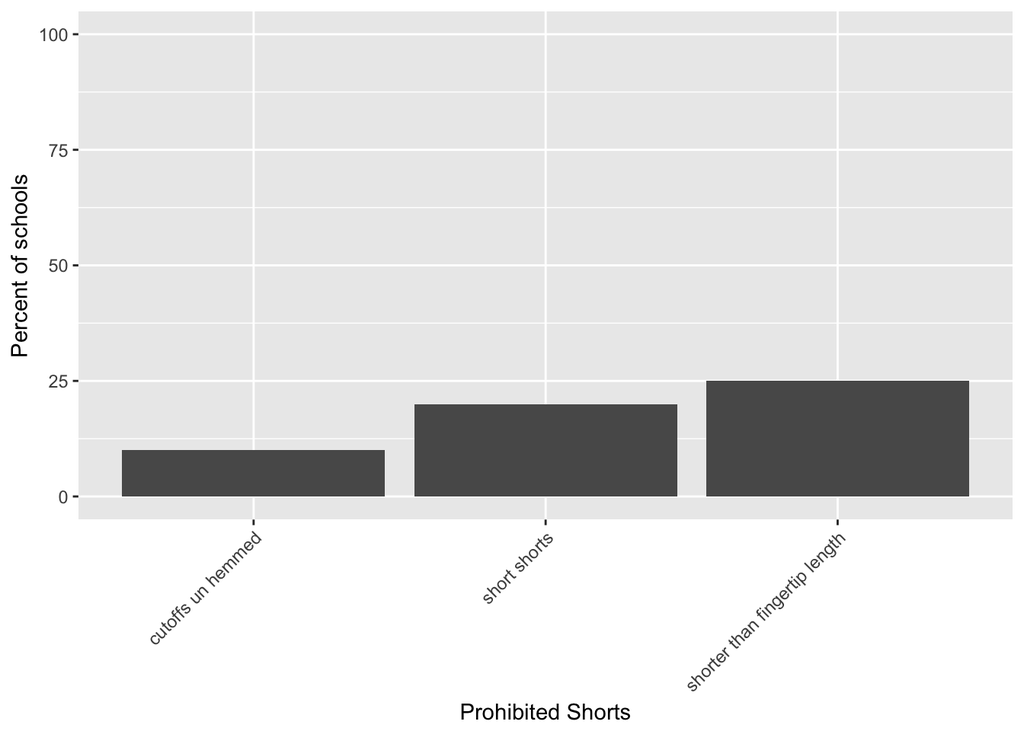

#### Pants

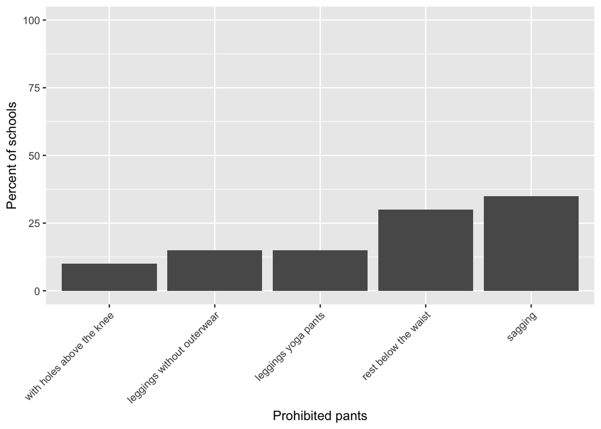

#### Skirts

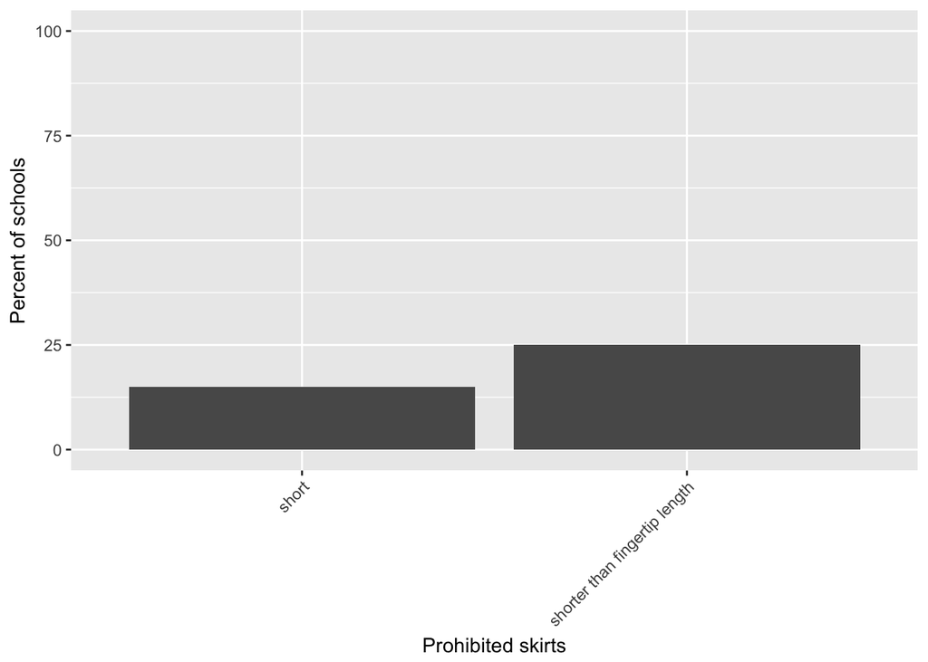

#### Dresses

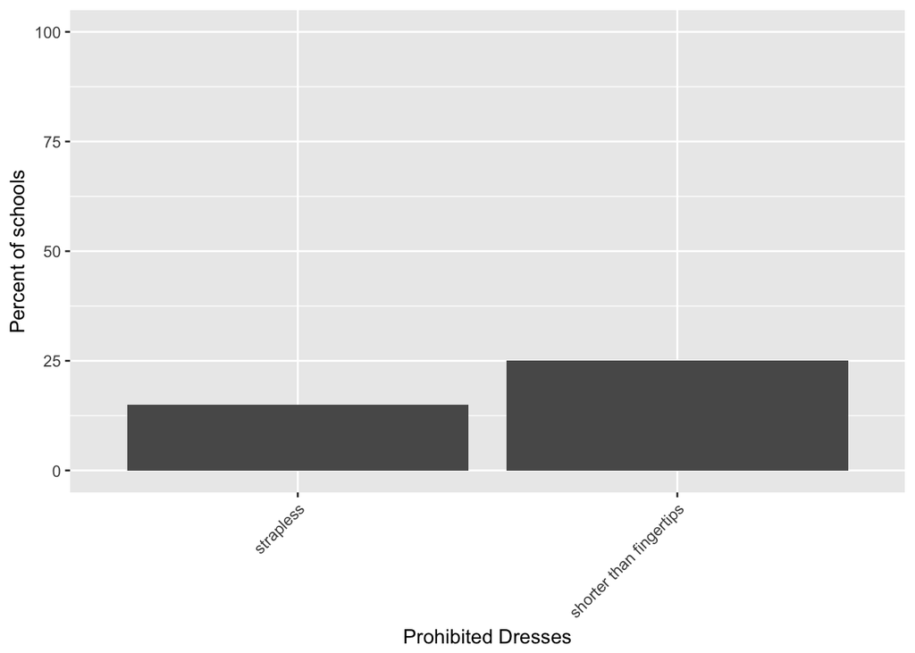

#### Accessories

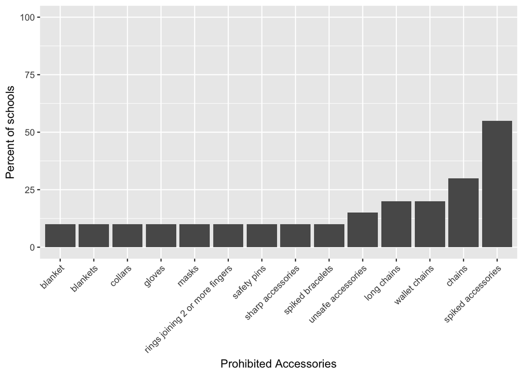

#### Footwear

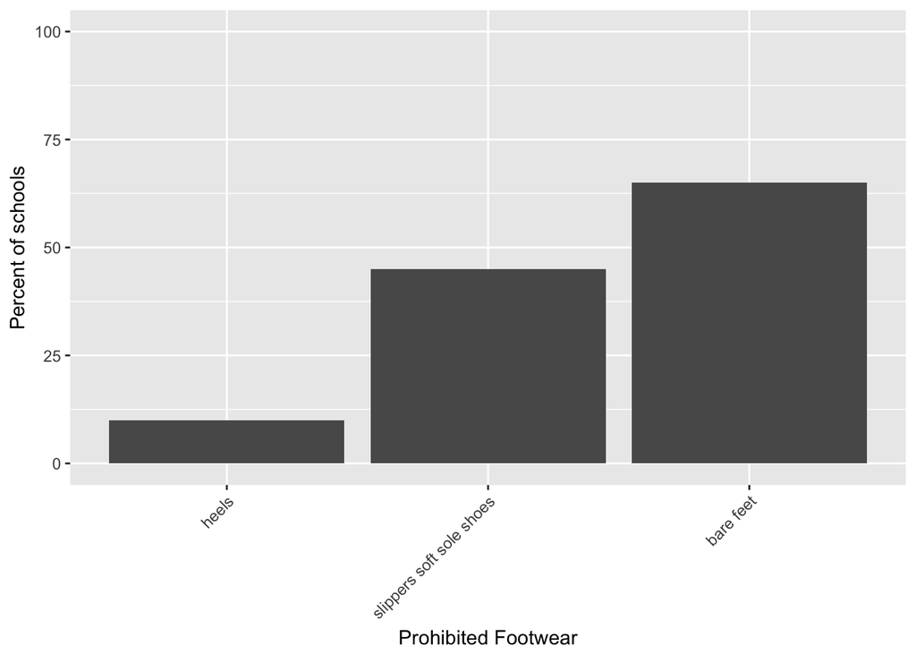

#### Undergarments

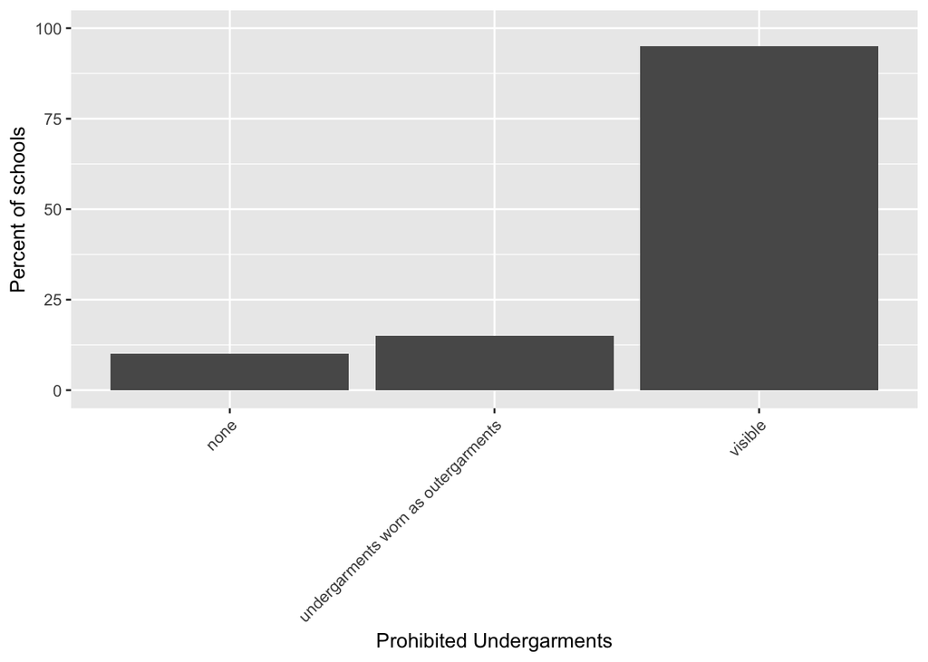

#### Headwear

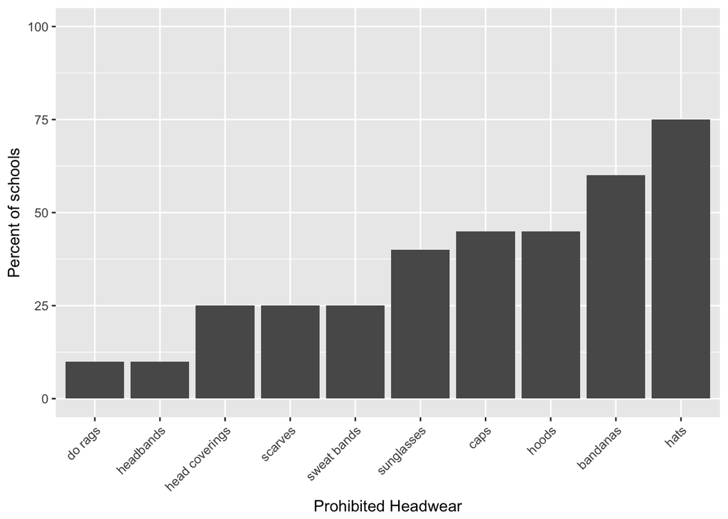

### Clothing Attributes

Sometimes descriptive words are used instead of explicit clothing items (showing items prohibited by a minimum of 3 schools).

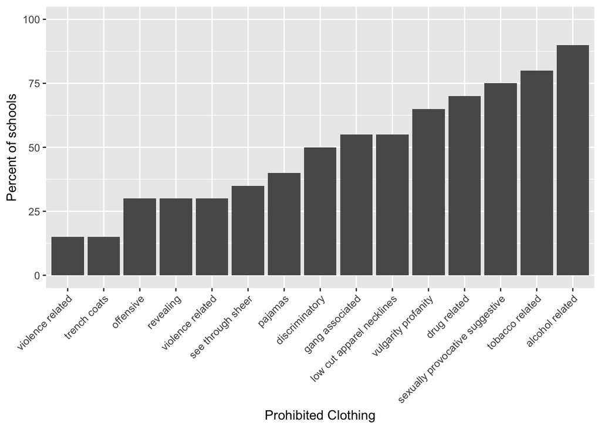

### Rationale

Typically before listing the actual items that are prohibited, schools give a brief rationale for why their dress codes exist. What words show up the most there?

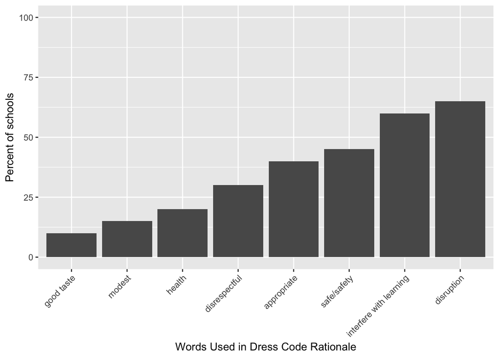

### Punishment

What types of punishements are schools requiring for dress code violations?

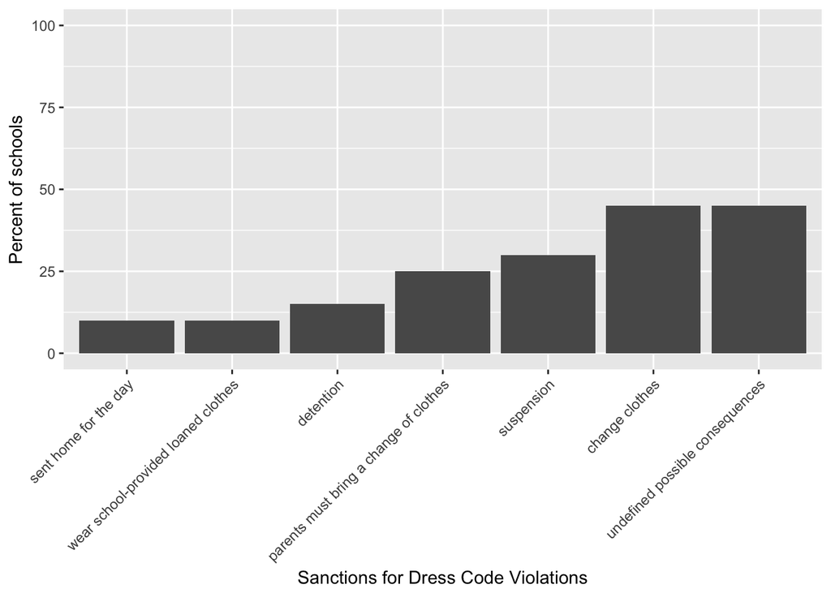

### Rules per School

What does the distribution look like in terms of prohibited items per school? (Currently based on one school per state)

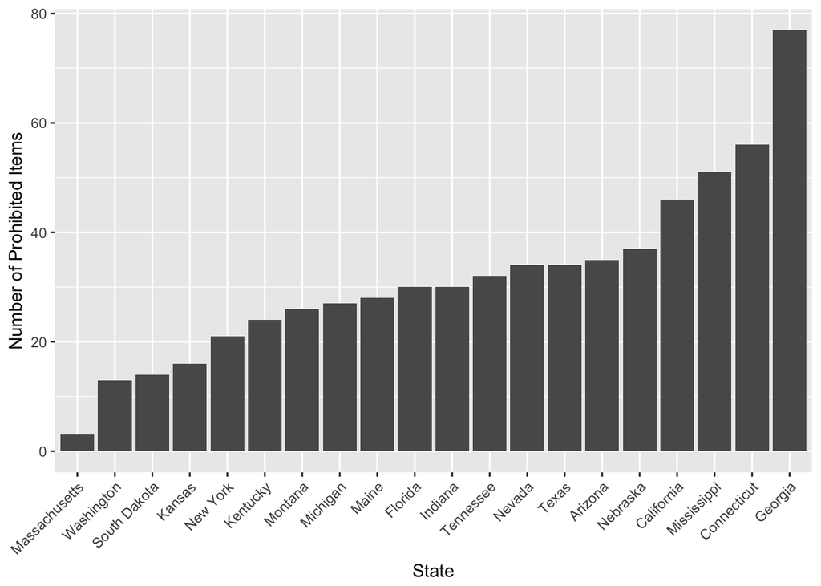

```r
perSchool <- longDressCode %>%
  count(School.State)

ggplot(perSchool, aes(x = reorder(School.State, n), y = n)) + geom_bar(stat = "identity") +
    theme(axis.text.x = element_text(angle = 45, hjust = 1)) +
  xlab("State") + ylab("Number of Prohibited Items")
```